# Analisis datos viajeros-Hospedaje

#### Variable N. dias estadia

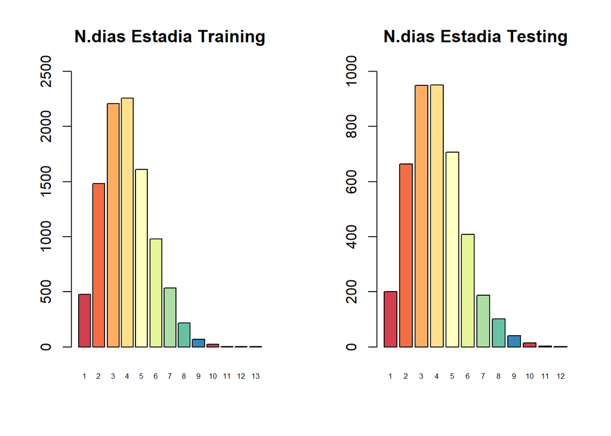

```r
# Grafico variable dias estadia.
par(mfrow=c(1,2))
barplot(table(datos.limpios$`#dias.estadia`), beside = TRUE, main="N.dias Estadia Training",
col=paleta.colores, width = 0.5, ylim=c(0,2500), cex.names=0.5)
barplot(table(testing.crudo$`#dias.estadia`), beside = TRUE, main="N.dias Estadia Testing",
col=paleta.colores, width = 0.5, ylim=c(0,1000),cex.names=0.5)
```

vemos a partir de las graficas que la cantidad de dias tiene una tendencia cercana a una distribución normal, concentrandose la mayor cantidad de los datos entre los 1 a 8 dias de estandia. Podria ser de algun interes posterior dicha tendencia.

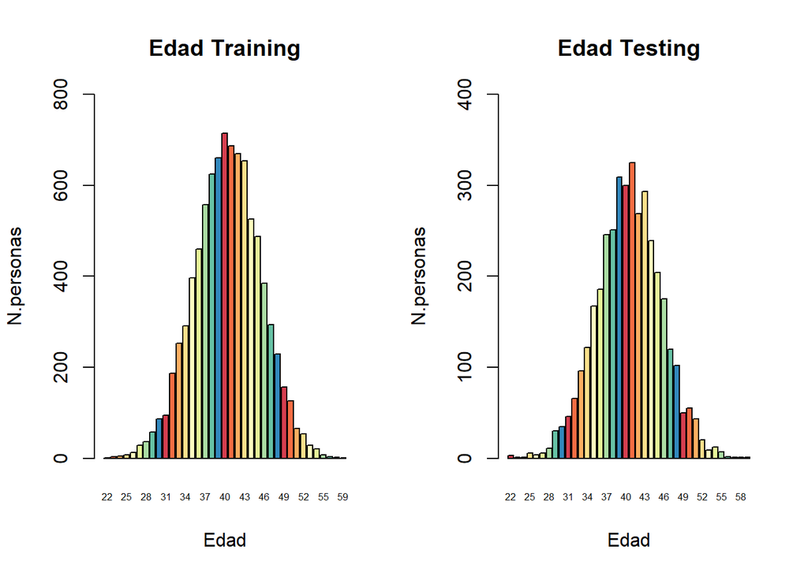

```r
# Grafico variable Edad .
par(mfrow=c(1,2))
barplot(table(datos.limpios$Edad), beside = TRUE, main="Edad Training", col=paleta.colores,
width = 0.5, cex.names=0.5, ylim = c(0,800), xlab = "Edad", ylab = "N.personas")
barplot(table(testing.crudo$Edad), beside = TRUE, main="Edad Testing", col=paleta.colores,
width = 0.5,cex.names=0.5, ylim = c(0,400), xlab = "Edad", ylab = "N.personas")
```

Las edades parecen tener una distribución cercana a la normal con media 40 años.

```r
par(mfrow=c(1,2))
# valores NA dentro de la variable edad
#los valores n.a en los datos de destino training
barplot(table(is.na(datos.limpios$Edad)), main=" NA - Edad train", ylim = c(0,10000),
col=paleta.colores, names.arg = c("NO.NA", "NA") )
porcentajes.destinos=prop.table(table(datos.limpios$Codigo.destino))
porcentajes.destinos*100
```

```
##
##     <NA>       BE       DK       ES       FI       IT       NL       SE
##  0.00000 13.08611 12.34220 11.92516 12.47746 12.55636 12.40983 12.96213
##       UK
## 12.24076
```

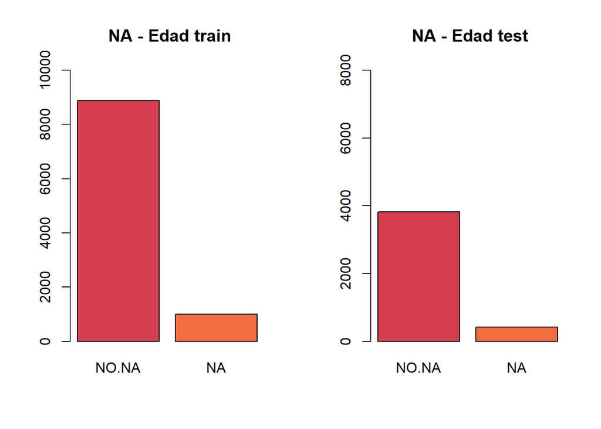

```r
#los  valores de n.a en los datos de destino testing
barplot(table(is.na(testing.crudo$Edad)), main=" NA - Edad test", ylim = c(0,8000),
col=paleta.colores,
names.arg = c("NO.NA", "NA") )
```

```r
porcentajes.destinos=prop.table(table(datos.limpios$Codigo.destino))
porcentajes.destinos*100
```

```
##
##     <NA>       BE       DK       ES       FI       IT       NL       SE
##  0.00000 13.08611 12.34220 11.92516 12.47746 12.55636 12.40983 12.96213
##       UK
## 12.24076
```

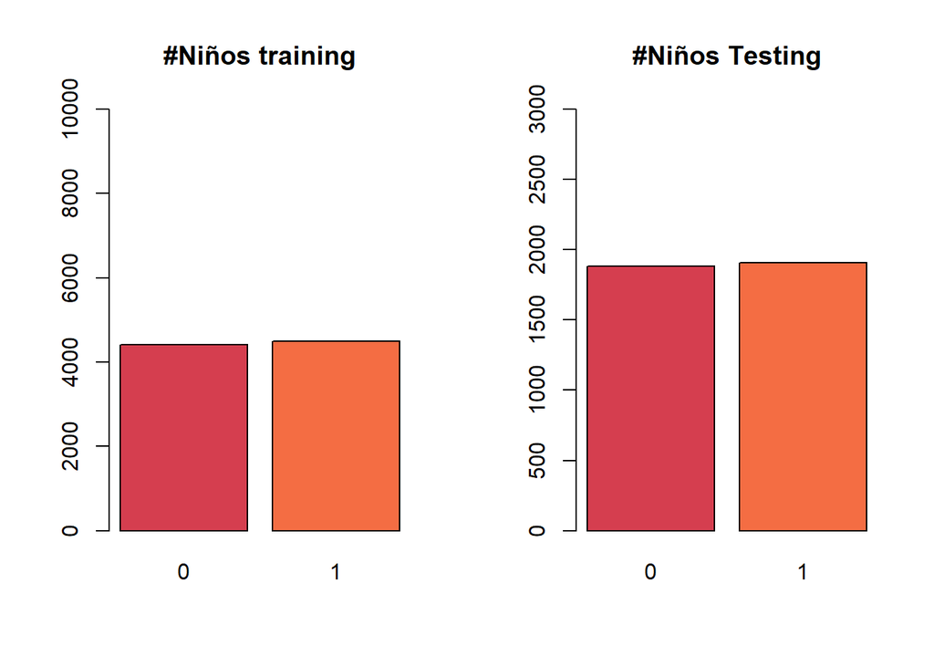

```r
#datos edades training
par(mfrow=c(1,2))
barplot(table(datos.limpios$`#Niños`), main="#Niños training", ylim = c(0,10000),
col=paleta.colores)
#edades testing
barplot(table(testing.crudo$`#Niños`), main="#Niños Testing",
ylim = c(0,3000), col=paleta.colores)
```

### Variable N.niños

```r
par(mfrow=c(1,2))
# valores n.a del training

barplot(table(is.na(datos.limpios$`#Niños`)), main=" NA - #Niños", ylim = c(0,10000),
col=paleta.colores, names.arg = c("NO.NA", "NA") )
porcentajes.destinos=prop.table(table(datos.limpios$Codigo.destino))
porcentajes.destinos*100
```

```
##
##     <NA>       BE       DK       ES       FI       IT       NL       SE
##  0.00000 13.08611 12.34220 11.92516 12.47746 12.55636 12.40983 12.96213
##       UK
## 12.24076
```

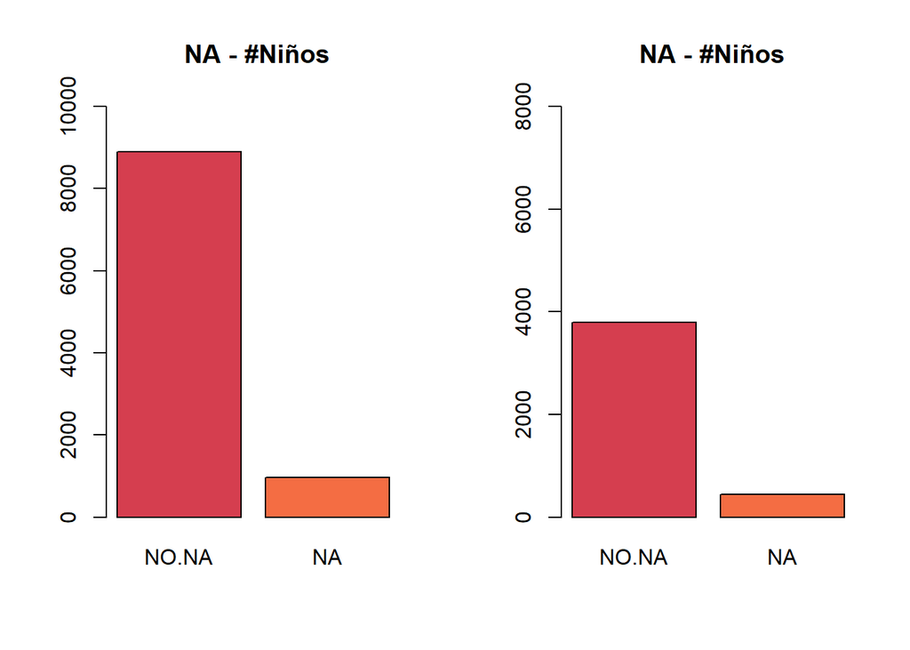

```r
#los  valores de n.a en los datos de destino testing
barplot(table(is.na(testing.crudo$`#Niños`)), main=" NA - #Niños", ylim = c(0,8000),
col=paleta.colores, names.arg = c("NO.NA", "NA") )
```

```r
porcentajes.destinos=prop.table(table(datos.limpios$Codigo.destino))
porcentajes.destinos*100
```

```
##
##     <NA>       BE       DK       ES       FI       IT       NL       SE
##  0.00000 13.08611 12.34220 11.92516 12.47746 12.55636 12.40983 12.96213
##       UK
## 12.24076
```

#### Variable Genero

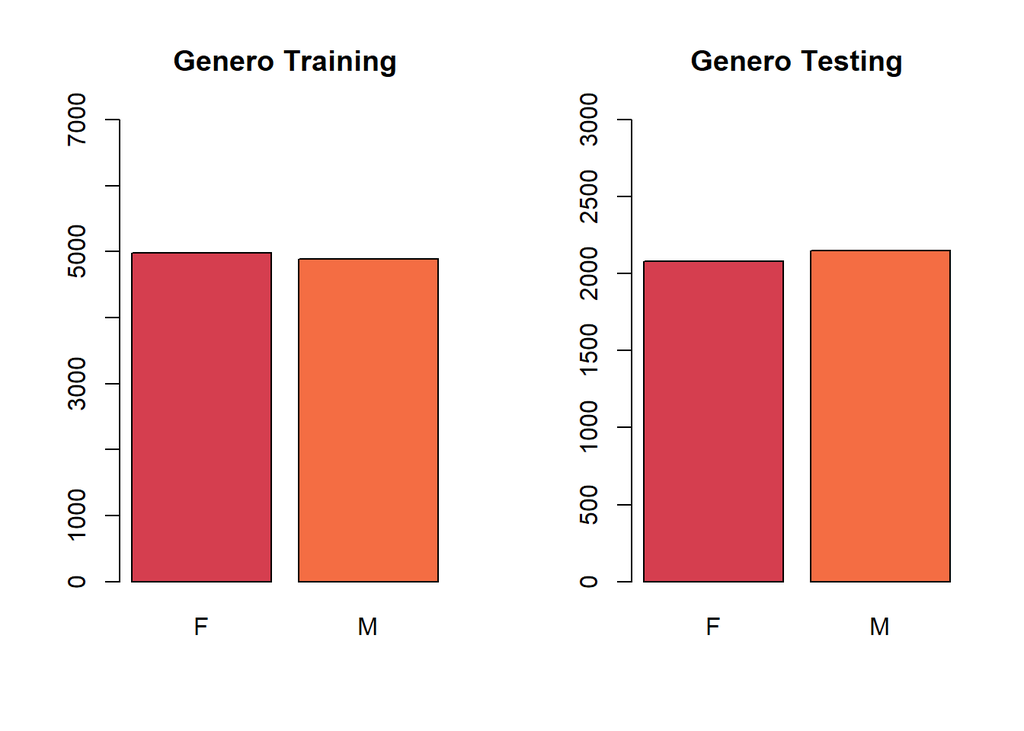

```r
# Grafico variable Genero
par(mfrow=c(1,2))
barplot(table(datos.limpios$Genero), beside = TRUE, main="Genero Training", col=paleta.colores,
width = 0.2, ylim = c(0, 7000) )
barplot(table(testing.crudo$Genero), beside = TRUE, main="Genero Testing", col=paleta.colores,
width = 0.2, ylim = c(0,3000))
```

#### Variable Ciudad Destino

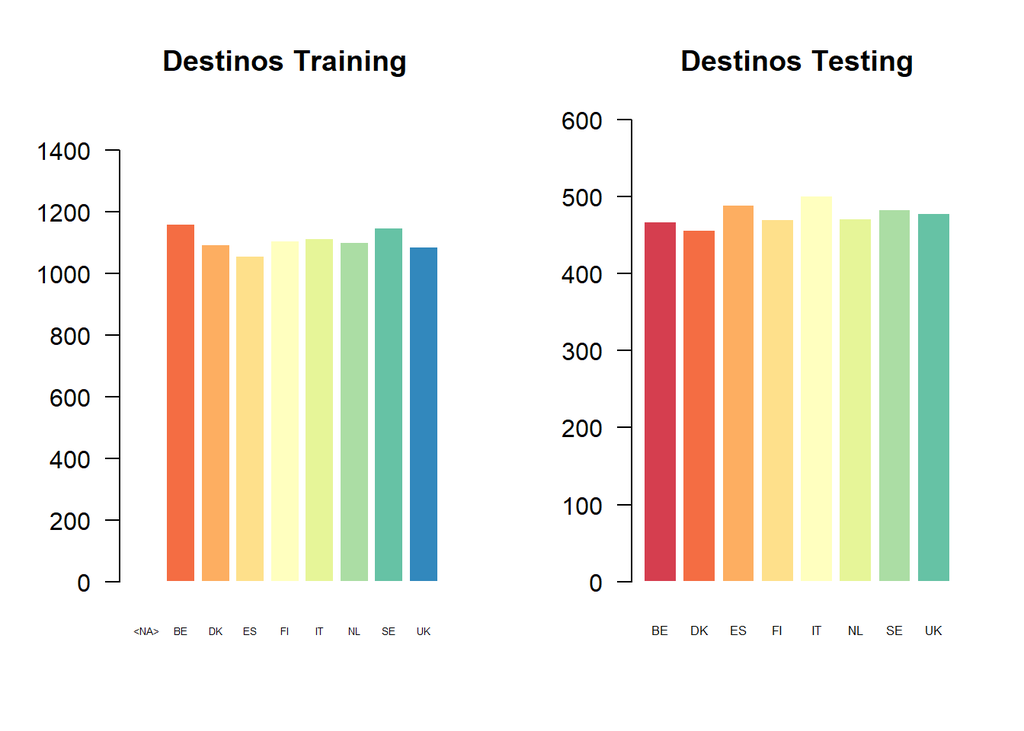

```r
par(mfrow=c(1,2))
destino.training=table(datos.limpios$Codigo.destino)

destino.testing=table(testing.crudo$Codigo.destino)
barplot(destino.training, beside=TRUE, ylim = c(0,1500), col = paleta.colores,las=1,
width = 0.46,border="white", main = "Destinos Training", cex.names = 0.4 )
barplot(destino.testing, beside=TRUE, ylim = c(0,600), col = paleta.colores,las=1,
width = 0.5,border="white", main = "Destinos Testing", cex.names = 0.5 )
```

La variable de lugar de destino presenta una cantidad significativa de valores faltantes. Por otro lado la cantidad de vistantes por destino es equilibrado entre los destinos mostrados.

```r
par(mfrow=c(1,2))
#los valores n.a en los datos de destino training
barplot(table(is.na(datos.limpios$Codigo.destino)), main=" NA - destinos", ylim = c(0,10000),
col=paleta.colores, names.arg = c("NO.NA", "NA") )
porcentajes.destinos=prop.table(table(datos.limpios$Codigo.destino))
porcentajes.destinos*100
```

```
##
##     <NA>       BE       DK       ES       FI       IT       NL       SE
##  0.00000 13.08611 12.34220 11.92516 12.47746 12.55636 12.40983 12.96213
##       UK
## 12.24076
```

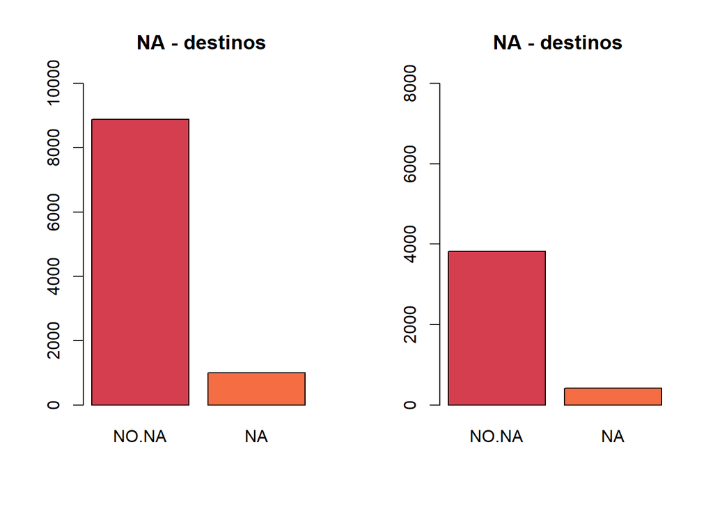

```r
#los valores de n.a en los datos de destino testing
barplot(table(is.na(testing.crudo$Codigo.destino)), main=" NA - destinos", ylim = c(0,8000),
col=paleta.colores, names.arg = c("NO.NA", "NA") )
```

```r
porcentajes.destinos=prop.table(table(testing.crudo$Codigo.destino))
porcentajes.destinos*100
```

```
##
##       BE       DK       ES       FI       IT       NL       SE       UK
## 12.23795 11.97589 12.81447 12.31656 13.12893 12.34277 12.65723 12.52621
```